# NOAA Storm Data Analysis

Danish Tamboli

7/21/2020

### Synopsis

#### The NOAA Dataset consists of readings from 1950-2011, with readings being taken more frequently in the later years, Analysis of the NOAA Storm Data is being carried out in hopes of finding the answer to the following questions:

#### Across the United States, which types of events (as indicated in the [EVTYPE] variable) are most harmful with respect to population health?

##### Calculated Taking the following variables into account:

- EVTYPE
- FATALITIES
- INJURIES

#### Across the United States, which types of events have the greatest economic consequences?

##### Calculated Taking the following variables into account:

- EVTYPE
- PROPDMG
- CROPDMG

## Data Processing

#### Downloading the U.S. National Oceanic and Atmospheric Administration’s (NOAA) Storm Dataset.

```r
if(!file.exists("NOAA_Strom_Data.csv.bz2")){
        download.file("https://d396qusza40orc.cloudfront.net/repdata%2Fdata%2FStormData.csv.bz2","NOAA_Strom_Data.csv.bz2")
}
```

#### Reading and Storing the Dataset using read.csv function.

```r
NOAA_Storm_Data <- read.csv("NOAA_Strom_Data.csv.bz2")
```

#### Lets have a look at the first 6 lines of the Dataset and An Overview of the classes of the Collumns present in the dataset.

```r
head(NOAA_Storm_Data)
```

```
##   STATE__           BGN_DATE BGN_TIME TIME_ZONE COUNTY COUNTYNAME STATE  EVTYPE
## 1       1  4/18/1950 0:00:00     0130       CST     97     MOBILE    AL TORNADO
## 2       1  4/18/1950 0:00:00     0145       CST      3    BALDWIN    AL TORNADO
## 3       1  2/20/1951 0:00:00     1600       CST     57    FAYETTE    AL TORNADO
## 4       1   6/8/1951 0:00:00     0900       CST     89    MADISON    AL TORNADO
## 5       1 11/15/1951 0:00:00     1500       CST     43    CULLMAN    AL TORNADO
## 6       1 11/15/1951 0:00:00     2000       CST     77 LAUDERDALE    AL TORNADO
##   BGN_RANGE BGN_AZI BGN_LOCATI END_DATE END_TIME COUNTY_END COUNTYENDN
## 1         0                                               0         NA
## 2         0                                               0         NA
## 3         0                                               0         NA
## 4         0                                               0         NA
## 5         0                                               0         NA
## 6         0                                               0         NA
##   END_RANGE END_AZI END_LOCATI LENGTH WIDTH F MAG FATALITIES INJURIES PROPDMG
```

[output cut: 20 more lines]

```r
str(NOAA_Storm_Data)
```

```
## 'data.frame':    902297 obs. of  37 variables:
##  $ STATE__   : num  1 1 1 1 1 1 1 1 1 1 ...
##  $ BGN_DATE  : chr  "4/18/1950 0:00:00" "4/18/1950 0:00:00" "2/20/1951 0:00:00" "6/8/1951 0:00:00" ...
##  $ BGN_TIME  : chr  "0130" "0145" "1600" "0900" ...
##  $ TIME_ZONE : chr  "CST" "CST" "CST" "CST" ...
##  $ COUNTY    : num  97 3 57 89 43 77 9 123 125 57 ...
##  $ COUNTYNAME: chr  "MOBILE" "BALDWIN" "FAYETTE" "MADISON" ...
##  $ STATE     : chr  "AL" "AL" "AL" "AL" ...
##  $ EVTYPE    : chr  "TORNADO" "TORNADO" "TORNADO" "TORNADO" ...
##  $ BGN_RANGE : num  0 0 0 0 0 0 0 0 0 0 ...
##  $ BGN_AZI   : chr  "" "" "" "" ...
##  $ BGN_LOCATI: chr  "" "" "" "" ...
##  $ END_DATE  : chr  "" "" "" "" ...
##  $ END_TIME  : chr  "" "" "" "" ...
##  $ COUNTY_END: num  0 0 0 0 0 0 0 0 0 0 ...
```

[output cut: 23 more lines]

#### Coverting the $BGN_DATE and $BGN_TIME from Character class to Date and POSIXlt respectively.

```r
MOD_NOAA_Storm_Data <- NOAA_Storm_Data
MOD_NOAA_Storm_Data$BGN_DATE <- as.Date(NOAA_Storm_Data$BGN_DATE, "%m/%d/%Y")
MOD_NOAA_Storm_Data$BGN_TIME <- strptime(paste(MOD_NOAA_Storm_Data$BGN_DATE,MOD_NOAA_Storm_Data$BGN_TIME),"%Y-%m-%d %H%M")
```

#### We see that now $BGN_DATE and $BGN_TIME are in their correct formats.

```r
str(MOD_NOAA_Storm_Data$BGN_DATE)
```

```
##  Date[1:902297], format: "1950-04-18" "1950-04-18" "1951-02-20" "1951-06-08" "1951-11-15" ...
```

```r
str(MOD_NOAA_Storm_Data$BGN_TIME)
```

```
##  POSIXlt[1:902297], format: "1950-04-18 01:30:00" "1950-04-18 01:45:00" "1951-02-20 16:00:00" ...
```

## Results

### Across the United States, which types of events (as indicated in the EVTYPE variable) are most harmful with respect to population health?

#### Finding Total Number of Fatalities and Injuries with respect to Event Type.

```r
# Checking if INJURIES AND FATALITIES CONTAIN ANY NA Values.
table(is.na(MOD_NOAA_Storm_Data$INJURIES))
```

```
##
##  FALSE
## 902297
```

```r
table(is.na(MOD_NOAA_Storm_Data$FATALITIES))
```

```
##
##  FALSE
## 902297
```

```r
# Seeing how many different types of Events Exist
length(table(MOD_NOAA_Storm_Data$EVTYPE))
```

```
## [1] 985
```

```r
# Finding The Total number of Injuries and Fatalities with respect to each Event.
total.injuries <- aggregate(INJURIES~EVTYPE,MOD_NOAA_Storm_Data,sum)
total.fatalities <- aggregate(FATALITIES~EVTYPE,MOD_NOAA_Storm_Data,sum)

# Merging Total Injuries and Fatalities into a single Dataframe and sorting it in Descending order, Number of Fatalities given higher importance than Injuries.
total.injuries.fatalities <- merge(total.injuries,total.fatalities,by = "EVTYPE")
total.injuries.fatalities <- total.injuries.fatalities[order(-total.injuries.fatalities$FATALITIES,-total.injuries.fatalities$INJURIES),]

# Picking the Top 5 and changing the colnames to more convinient ones.
total.injuries.fatalities.top5 <- total.injuries.fatalities[1:5,]
colnames(total.injuries.fatalities.top5) <- c("Event.Type","Injuries","Fatalities")

# Table of Total Injuries and Fatalities with respect to Event Type.
knitr::kable(total.injuries.fatalities.top5)
```

|  | Event.Type | Injuries | Fatalities |
| --- | --- | --- | --- |
| 834 | TORNADO | 91346 | 5633 |
| 130 | EXCESSIVE HEAT | 6525 | 1903 |
| 153 | FLASH FLOOD | 1777 | 978 |
| 275 | HEAT | 2100 | 937 |
| 464 | LIGHTNING | 5230 | 816 |

```r
# Calculating Cumulative Casualties (Fatalities+Injuries),in Descending order with respect to Different Events.
total.harm <- aggregate(FATALITIES+INJURIES~EVTYPE,MOD_NOAA_Storm_Data,sum)
total.harm <- total.harm[order(-total.harm$`FATALITIES + INJURIES`),]

# Selecting the Top 10 Casualties prone areas.
top5.total.harm <- total.harm[1:5,]
colnames(top5.total.harm) <- c("Event.Type","Total.Casualty")

# Table of Total Casualties varying with Different Events
knitr::kable(top5.total.harm)
```

|  | Event.Type | Total.Casualty |
| --- | --- | --- |
| 834 | TORNADO | 96979 |
| 130 | EXCESSIVE HEAT | 8428 |
| 856 | TSTM WIND | 7461 |
| 170 | FLOOD | 7259 |
| 464 | LIGHTNING | 6046 |

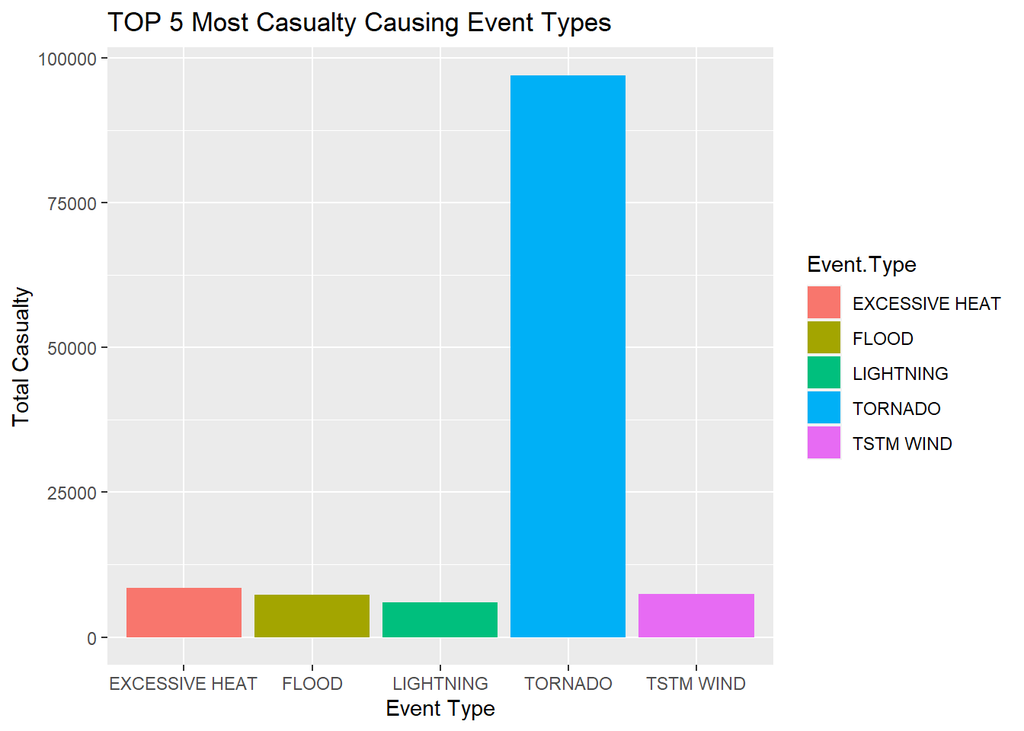

```r
#Loading the ggplot2 library for plotting
library(ggplot2)
# TOP 5 Most Casualty Causing / Most Harmful Event Types
ggplot(top5.total.harm,aes(Event.Type,Total.Casualty,fill=Event.Type)) + geom_col() + labs(x= "Event Type",y= "Total Casualty",title= "TOP 5 Most Casualty Causing Event Types")
```

#### We see that the Top 5 Most Harmful events are as follow:

- TORNADO
- EXCESSIVE HEAT
- TSTM WIND
- FLOOD
- LIGHTNING

## Across the United States, which types of events have the greatest economic consequences?

#### Calculating the Property and Crop Damages,along with Total Damages on a Event Type basis.

```r
# Calculating the Total property Damage of different Events.
property.damage <- aggregate(PROPDMG~EVTYPE,MOD_NOAA_Storm_Data,sum)

# Calculating the TOtal Crop Damange of different Events.
crop.damage <- aggregate(CROPDMG~EVTYPE,MOD_NOAA_Storm_Data,sum)

# Combining the Property and Crop Damage into a singe Dataframe.
economical.damage <- merge(property.damage,crop.damage,by="EVTYPE")

# Calculating total Economical Damage.
economical.damage <- cbind(economical.damage,Total.Damage = property.damage[,2] + crop.damage[,2])

colnames(economical.damage)<- c("Event.Type","Property.Damage","Crop.Damage","Total.Damage")

# Sorting the Economical Damage in Descending Order.
economical.damage <- economical.damage[order(-economical.damage$Total.Damage),]

# Filtering out the top 5 monst Economical Damange causing Events.
economical.damage.top.5 <- economical.damage[1:5,]

#Table of Events and the Damages Incured by them
knitr::kable(economical.damage.top.5)
```

|  | Event.Type | Property.Damage | Crop.Damage | Total.Damage |
| --- | --- | --- | --- | --- |
| 834 | TORNADO | 3212258.2 | 100018.5 | 3312277 |
| 153 | FLASH FLOOD | 1420124.6 | 179200.5 | 1599325 |
| 856 | TSTM WIND | 1335965.6 | 109202.6 | 1445168 |
| 244 | HAIL | 688693.4 | 579596.3 | 1268290 |
| 170 | FLOOD | 899938.5 | 168037.9 | 1067976 |

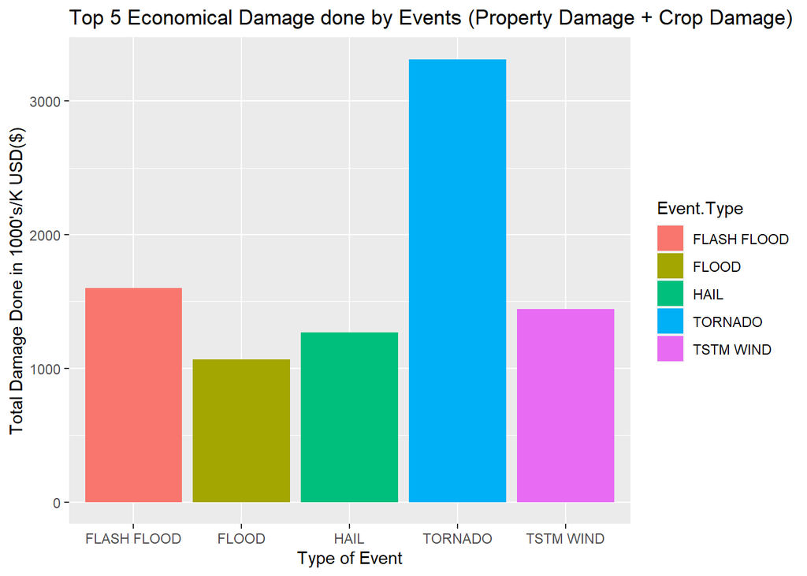

```r
ggplot(economical.damage.top.5,aes(Event.Type,Total.Damage/1000)) + geom_col(aes(fill=Event.Type)) + labs(x="Type of Event",y="Total Damage Done in 1000's/K USD($)",title = "Top 5 Economical Damage done by Events (Property Damage + Crop Damage)")
```

#### We see that the Top 5 Most Economy Damaging Types of Events are:

- TORNADO
- FLASH FLOOD
- TSTM WIND
- HAIL
- FLOOD